# Diamonds are Forever

Imelda Finn

09 September 2022

# Header 1 - Using R Markdown

## Header 2 - This is a Sub-Header

The `diamonds` dataset is a built-in dataset of the `ggplot` package. Yesterday, we analysed this data in an R script file. Today, we want to create a HTML document in which we present our findings. In the process, we will learn a little bit about how R Markdown files work.`

The current file you are reading is an R Markdown document, which outputs to a HTML document. It has the extension .rmd. It looks similar to a script file (.R), except in the banner above the file window you should see a couple of additional buttons - “Knit” and “+C”.

At the top of this file you will find three horizontal dashes, followed by four lines (title, author, date and output), and then another three dashes. This is a **YAML** header. YAML stands for “Yet Another Markup Language” (yes, really.)

Note that the “date” entry contains an excerpt of R code inside single back ticks `.

Following the YAML header, there is another excerpt of R code inside triple back ticks ```. This is a code **chunk**, and is the way we insert sections of code within an R Markdown file. This first chunk is the **setup** chunk, and just like a good script file it includes the package(s) we will be using in the document, as well as the default settings for chunk options. Here, we placed the default option “include = FALSE” in the curly brackets. This means R will run the code inside the chunks, but won’t include the text of the code in the output.

### Header 3 - This is a sub-sub-header(?)

After the first code “chunk” there is a hash symbol #. We use the hash symbol to create headers, sub-headers ## and sub-sub-headers ###.

# Let’s Get Some Data Up

We can use R Markdown to show our data. Let’s use the `head()` function to show the first 6 rows. Here’s the chunk -

```r
head(diamonds)
```

```
## # A tibble: 6 × 10
##   carat cut       color clarity depth table price     x     y     z
##   <dbl> <ord>     <ord> <ord>   <dbl> <dbl> <int> <dbl> <dbl> <dbl>
## 1  0.23 Ideal     E     SI2      61.5    55   326  3.95  3.98  2.43
## 2  0.21 Premium   E     SI1      59.8    61   326  3.89  3.84  2.31
## 3  0.23 Good      E     VS1      56.9    65   327  4.05  4.07  2.31
## 4  0.29 Premium   I     VS2      62.4    58   334  4.2   4.23  2.63
## 5  0.31 Good      J     SI2      63.3    58   335  4.34  4.35  2.75
## 6  0.24 Very Good J     VVS2     62.8    57   336  3.94  3.96  2.48
```

If we click the green “play” button inside our chunk, we will see the code output inside this document. Try it.

The result is quite nicely presented. If we wanted to make a more “professional” looking table though, we could use the `kable()` function in the `knitr` package. Because we didn’t load knitr in our setup chunk, we need to call both the package and the function in our chunk using double colons (i.e., package::function).

```r
knitr::kable(head(diamonds), caption = "a knitr kable")
```

a knitr kable

| carat | cut | color | clarity | depth | table | price | x | y | z |
| --- | --- | --- | --- | --- | --- | --- | --- | --- | --- |
| 0.23 | Ideal | E | SI2 | 61.5 | 55 | 326 | 3.95 | 3.98 | 2.43 |
| 0.21 | Premium | E | SI1 | 59.8 | 61 | 326 | 3.89 | 3.84 | 2.31 |
| 0.23 | Good | E | VS1 | 56.9 | 65 | 327 | 4.05 | 4.07 | 2.31 |
| 0.29 | Premium | I | VS2 | 62.4 | 58 | 334 | 4.20 | 4.23 | 2.63 |
| 0.31 | Good | J | SI2 | 63.3 | 58 | 335 | 4.34 | 4.35 | 2.75 |
| 0.24 | Very Good | J | VVS2 | 62.8 | 57 | 336 | 3.94 | 3.96 | 2.48 |

Which do you prefer? Kable seems to have nicer formatting.

# Now Let’s Try a Plot

## Are Better Diamonds Really Cheaper?

In our analysis yesterday we noticed that something funny was going on with the average price of diamonds by quality of cut: it seemed that *better* quality diamonds were, on average, *cheaper*.

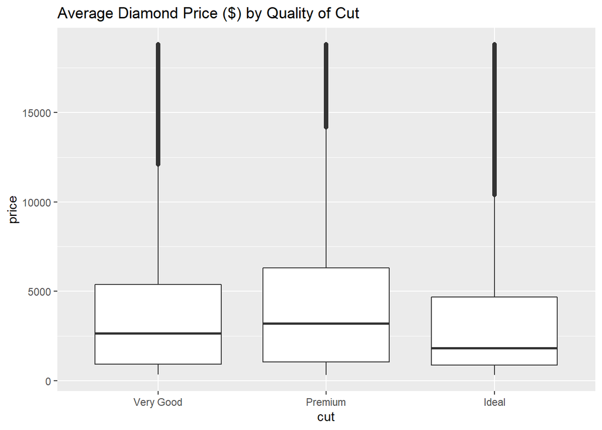

```r
diamonds %>%
  filter(cut %in% c("Ideal", "Premium", "Very Good")) %>%
  group_by(cut) %>%
  ggplot(aes(cut, price)) +
    geom_boxplot() +
    labs(title = "Average Diamond Price ($) by Quality of Cut")
```

Here, take a quick look inside the curly braces {} after the three back ticks. The first entry, “r”, tells R Markdown what language to expect the code chunk to be in. After this, we have a space and the chunk name - “cut-boxplot”. This is then followed by two optional arguments, separated by commas. The first, “out.width”, determines the width of the output as a percentage of the document width. The second, “fig.align”, determines which side of the page to align the figure.

## Or Are Lower Quality Diamonds Simply Bigger?

You may recall that our initial finding - that better diamonds are cheaper - was actually an artifact of our data: better diamonds tend to be smaller, and diamonds are valued by weight. You were asked yesterday to change the code for the first box plot to compare cut by carat. Add a new chunk below with that plot (either copy/paste it from yesterday’s script file, or adapt the chunk above. Don’t forget the title!)

# Let’s Round It Off

Usually you would want to finish your analysis on a strong conclusion. Let’s put in out final line plot from yesterday.

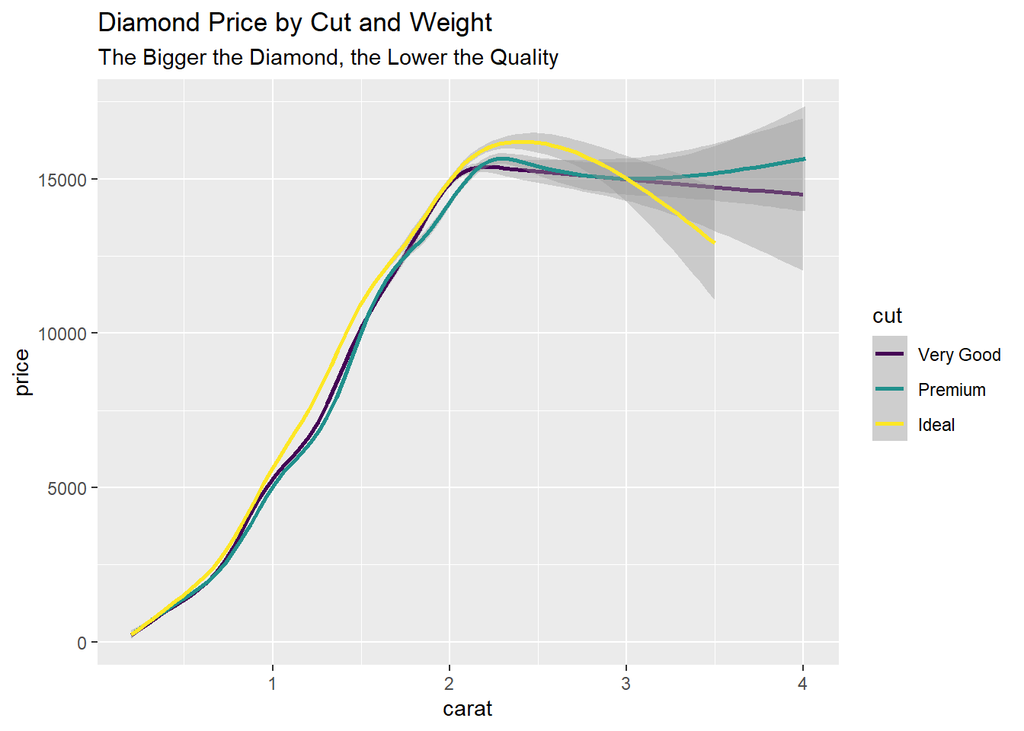

```r
diamonds %>%
  filter(cut %in% c("Ideal", "Premium", "Very Good")) %>%
  group_by(cut) %>%
  ggplot(aes(carat, price, color = cut)) +
  geom_smooth() +
  labs(title = "Diamond Price by Cut and Weight", subtitle = "The Bigger the Diamond, the Lower the Quality")
```

Finish this report off with a couple of sentences of your own that interpret this plot for the reader. Once you’re done, press the “knit” button and see what happens (don’t forget to click the “open in browser” option as well.)